# DATA 606 Data Project: Causes of Financial Wellbeing

David Simbandumwe

## Setup

```r
# Exported data load, tidy function and tibble cleaning
fun_file_name <- glue(getwd(), "/Project/DATA606_Functions.R")
source(fun_file_name, local = knitr::knit_global())
```

# Abstract

The deregulation of the financial services industry has provided more investment opportunities for individuals and families but it has also increased the level of financial knowledge necessary to make good decisions. It is no coincidence that these trends have driven an increased focus in financial health and financial wellbeing by individuals, employers, government agencies and financial services firms. Understanding financial wellness requires a clear definition of wellness, an approach to measuring differences in wellbeing, and an understanding the factors that influence consumer financial wellness.

This project adopts the definition and measurement methodology developed by the Consumer Financial Protection Bureau as part of their ongoing research efforts. The CFPB defines financial wellness as the “…sense of financial security and freedom of choice—both in the present and when considering the future”. The CFPB has developed a measurement of consumer financial wellbeing called the Financial Wellbeing Scale (CFPB Score). The CFPB methodology includes a survey that not only captures the 10 questions necessary to calculate the CFPB score but includes additional attributes that paint a holistic financial and demographic picture of an individual or family.

This analysis will utilize the data from the CFPB Survey. Starting with the non calculated variables linear regression will be used to evaluate the relationship between non scoring attributes demographic, financial, house hold structure characteristics and the CFPB Score.

(Please note that the 10 questions that are used to calculate the CFPB Score are not included in the attributes evaluated in this analysis)

# Part 1 - Introduction

This analysis is focused on understanding the factors that impact consumer financial wellbeing. There are numerous sources of analysis, theory and survey data however for the purposes of this project I will focus on the work from the Consumer Financial Protection Bureau National Financial Well-Being Survey Public Use File (PUF). The PUF survey data allows us to analyze a CFPB Score of consumer wellbeing in association with an individuals financial and demographic characteristics. Linear regression will be used to quantify the impact of individual factors and create a predictive model of financial wellbeing.

**Analysis Steps** In addition to the outline provided for the project that analysis will follow that steps below.

1. Review the survey data including the cfpb score
2. Select subset of 217 variables in the survey to analyze
3. Explore the relationship between individual variables and the cfpb score
4. Fit the full model using linear regression
5. Optimize the model using stepwize regression
6. Fit a models focused on financial planning variables and demographic variables respectively
7. Explore impacts of survey variables on cfpb score

# Part 2 - Data

The data was collected as part of the Consumer Financial Protection Bureau’s (CFPB) National Financial Well-Being Survey Public Use File (PUF). The PUF is a dataset containing

1. data collected in the National Financial Well-Being Survey,
2. data about members of the GfK KnowledgePanel collected prior to the survey, and
3. data on poverty levels in respondents’ counties of residence.

The National Financial Well-Being Survey was conducted in English and Spanish via web mode between October 27, 2016 and December 5, 2016. Overall, 6,394 surveys were completed: 5,395 from the general population sample and 999 from an oversample of adults aged 62 and older. The survey was designed to represent the adult population of the 50 U.S. states and the District of Columbia. The survey was fielded on the GfK KnowledgePanel®. The KnowledgePanel sample is recruited using address-based sampling and dual-frame landline and cell phone random digit dialing methods.

The PUF was published in 2017.

**Load data and review summary stats**

Limited filtering of observations conducted as part of this analysis Other answers such as “refuse to answer” or “do not know” actual contain some relevant information in the context of a individuals financial characteristics. This can be seen in the prevalence of these answers in the dataset roughly 2/3 or the observations include at least one survey answer in the other category.

```r
# full dataset
cfpbRaw_df <- getRawCFPBFile()


# load data - logic for data tidying is associated DATA606_Functions.R file
cfpb_df <- getReducedCFPBFile()
cfpb_df <- cfpb_df %>% droplevels()


# Filter records with invalid cfpb scores
cfpb_df <- cfpb_df %>% filter( cfpb_score > 0)
```

```r
summary(cfpb_df)
```

```
##    cfpb_score                 econ_hh_income              econ_inc_volatility
##  Min.   :14.00   $100,000 to $149,999:1114   Refused                :  61
##  1st Qu.:48.00   $75,000 to $99,999  : 954   Roughly the same       :4611
##  Median :56.00   $150,000 or more    : 861   some unusually spending:1303
##  Mean   :56.08   Less than $20,000   : 717   varies quite a bit     : 414
##  3rd Qu.:65.00   $60,000 to $74,999  : 651
##  Max.   :95.00   $30,000 to $39,999  : 614
##                  (Other)             :1478
##       econ_hh_earners       econ_emp_status            econ_savings
##  Refused      :  75   full-time     :2491   $5,000-19,999    :1093
##  One          :2440   Retired       :1837   Prefer not to say: 987
##  Two          :3532   part-time     : 432   $1,000-4,999     : 931
##  More than two: 342   Self-employed : 418   $20,000-74,999   : 845
##                       Homemaker     : 358   $75,000 or more  : 834
##                       unable to work: 269   $100-999         : 682
##                       (Other)       : 584   (Other)          :1017
##                           hh_status                  hh_value
##  Refused                       :  39   Question not asked:2226
##  I own my home                 :4163   $150,000-249,999  :1053
##  I rent                        :1642   Less than $150,000:1034
##  I do not currently own or rent: 545   $250,000-399,999  : 991
##                                        $400,000 or more  : 804
##                                        Prefer not to say : 159
##                                        (Other)           : 122
##              hh_mortgage       per_health
##  Question not asked:2226   Refused  :  52
##  Refused           :  56   Poor     : 154
##  Less than $50,000 :1512   Fair     : 780
##  $50,000-199,999   :1360   Good     :2137
##  $200,000 or more  : 622   Very good:2582
##  I don't know      : 115   Excellent: 684
##  Prefer not to say : 498
##                                hh_arrange   hh_size
##  Refused                            :  28   1 :1227
##  only adult in the household        :1128   2 :2702
##  spouse/partner/significant other   :4204   3 : 996
##  my parents' home                   : 450   4 : 817
##  other family, friends, or roommates: 453   5+: 647
##  Some other arrangement             : 126
##
```

[output cut: 33 more lines]

```
##  Refused                   :   6    Refused                   :   6
##  Strongly disagree         : 132    Strongly disagree         : 127
##  Disagree                  : 653    Disagree                  : 528
##  Neither agree nor disagree:1629    Neither agree nor disagree:1625
##  Agree                     :2985    Agree                     :3088
##  Strongly agree            : 984    Strongly agree            :1015
##
##                     fin_clear_plan
##  Refused                   :   6
##  Strongly disagree         : 265
##  Disagree                  :1197
##  Neither agree nor disagree:2208
##  Agree                     :2034
##  Strongly agree            : 679
##
```

The cfpb score for this survey data is near normaly distributed with outlines at the high end and low end of the scoring distribution.

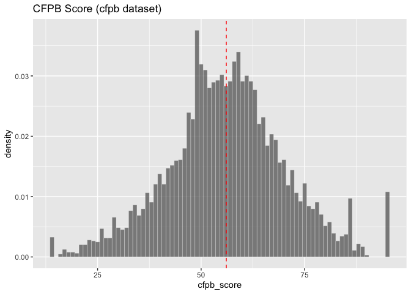

```r
# cfpb
ggplot(cfpb_df,
    aes(cfpb_score, y = stat(density))) +
    geom_histogram(binwidth = 1, alpha = 0.7, bins = 100, color="white",size = 0.1) +
    geom_vline(aes(xintercept = mean(cfpb_score)), linetype = "dashed", color="red", size = 0.5) +
    scale_fill_brewer(palette="Spectral") +
    labs(title = "CFPB Score (cfpb dataset)")
```

```r
summary(cfpb_df$cfpb_score)
```

```
##    Min. 1st Qu.  Median    Mean 3rd Qu.    Max.
##   14.00   48.00   56.00   56.08   65.00   95.00
```

**House Hold Income**

As would be expected the histogram and the box plot for cfpb score categorized by house hold income shows some positive correlation between house hold income and the cfpb_score.

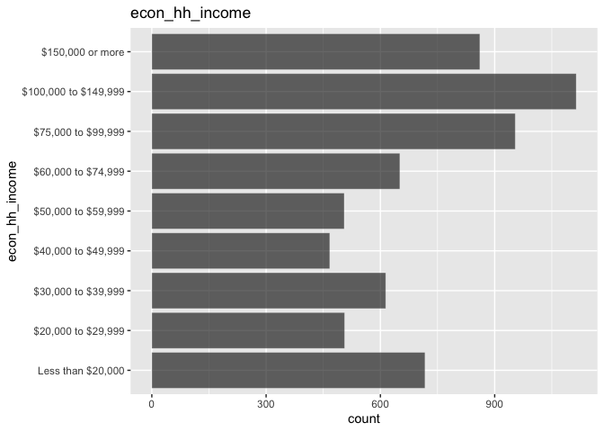

```r
# econ_hh_income
ggplot(cfpb_df, aes(x=econ_hh_income)) +
  geom_bar(color="white", fill="black", alpha = 0.6, size = 0.1) +
  coord_flip() +
  labs(title = "econ_hh_income")
```

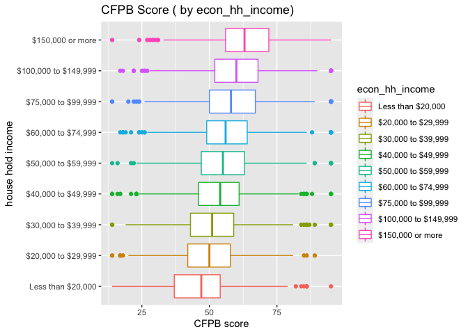

```r
ggplot(data = cfpb_df) +
  geom_boxplot(mapping = aes(x=cfpb_score, y=econ_hh_income, color=econ_hh_income)) +
  labs (title="CFPB Score ( by econ_hh_income)", x="CFPB score", y="house hold income")
```

[figure not shown]

```r
ggplot(cfpb_df,
    aes(cfpb_score, fill = econ_hh_income, y = stat(density))) +
    geom_histogram(binwidth = 1, alpha = 0.7, bins = 100, color="white",size = 0.1) +
    geom_vline(aes(xintercept = mean(cfpb_score)), linetype = "dashed", size = 0.2) +
    scale_fill_brewer(palette="Spectral") +
    labs(title = "CFPB Score (by econ_hh_income)")
```

**Age**

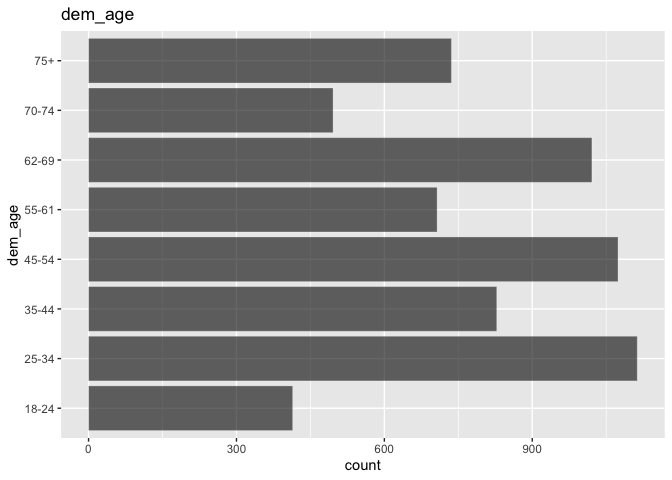

```r
# dem_age
ggplot(cfpb_df, aes(x=dem_age)) +
  geom_bar(color="white", fill="black", alpha = 0.6, size = 0.1) +
  coord_flip() +
  labs(title = "dem_age")
```

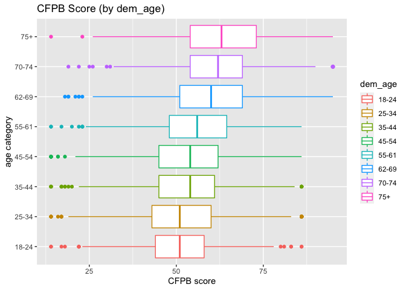

```r
ggplot(data = cfpb_df) +
  geom_boxplot(mapping = aes(x=cfpb_score, y=dem_age, color=dem_age)) +
  labs (title = "CFPB Score (by dem_age)", x="CFPB score", y="age category")
```

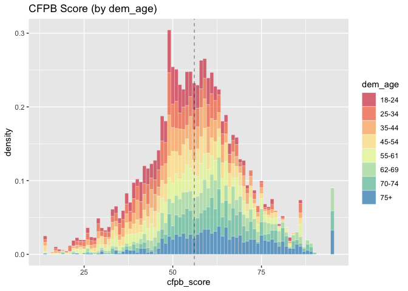

```r
ggplot(cfpb_df,
    aes(cfpb_score, fill = dem_age, y = stat(density))) +
    geom_histogram(binwidth = 1, alpha = 0.7, bins = 100, color="white",size = 0.1) +
    geom_vline(aes(xintercept = mean(cfpb_score)), linetype = "dashed", size = 0.2) +
    scale_fill_brewer(palette="Spectral") +
    labs(title = "CFPB Score (by dem_age)")
```

**Achieve Financial Goals**

The relationship between sfpb_score and confidence in reaching your financial goals is intriguing It highlights a positive relationship between confidence in financial goals and cfpb score. The box plot and histogram show a wide range of survey respondents are optimistic even if their cfpb scores would indicate otherwise.

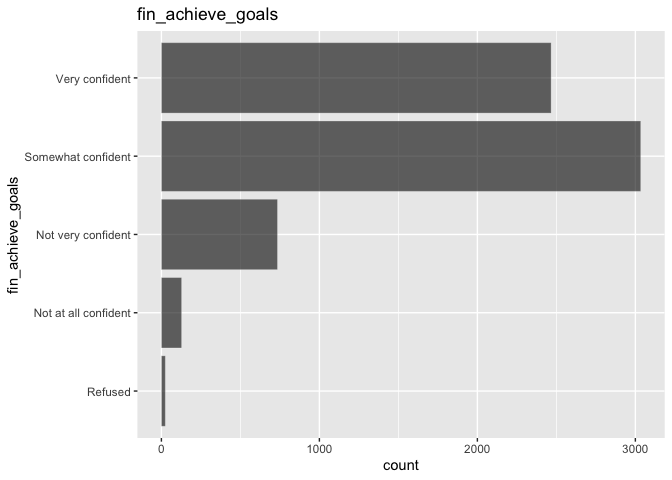

```r
# fin_achieve_goals
ggplot(cfpb_df, aes(x=fin_achieve_goals)) +
  geom_bar(color="white", fill="black", alpha = 0.6, size = 0.1) +
  coord_flip() +
  labs(title = "fin_achieve_goals")
```

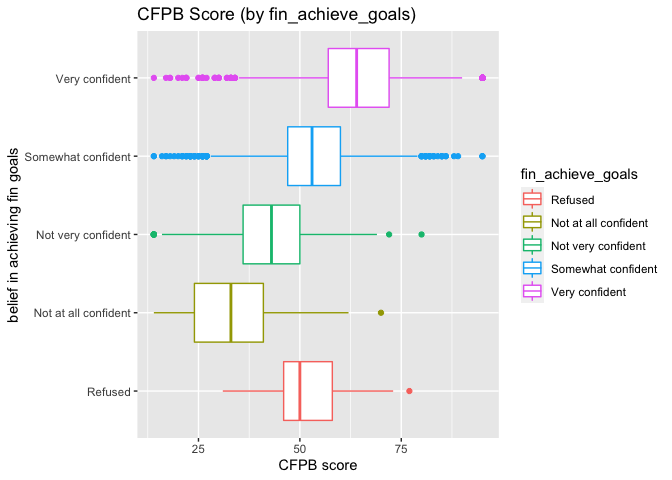

```r
ggplot(data = cfpb_df) +
  geom_boxplot(mapping = aes(x=cfpb_score, y=fin_achieve_goals, color=fin_achieve_goals)) +
  labs (title = "CFPB Score (by fin_achieve_goals)", x="CFPB score", y="belief in achieving fin goals")
```

[figure not shown]

```r
ggplot(cfpb_df,
    aes(cfpb_score, fill = fin_achieve_goals, y = stat(density))) +
    geom_histogram(binwidth = 1, alpha = 0.7, bins = 100, color="white",size = 0.1) +
    geom_vline(aes(xintercept = mean(cfpb_score)), linetype = "dashed", size = 0.2) +
    scale_fill_brewer(palette="Spectral") +
    labs(title = "CFPB Score (by fin_achieve_goals)")
```

**Health**

Given the structure of the health care system in the United States it is unsurprising that health shows a positive correlated cfpb score.

[figure not shown]

```r
# per_health
ggplot(cfpb_df, aes(x=fin_frugal)) +
  geom_bar(color="white", fill="black", alpha = 0.6, size = 0.1) +
  coord_flip() +
  labs(title = "per_health")
```

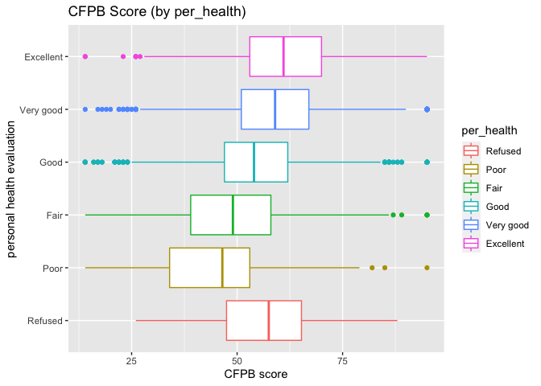

```r
ggplot(data = cfpb_df) +
  geom_boxplot(mapping = aes(x=cfpb_score, y=per_health, color=per_health)) +
  labs (title = "CFPB Score (by per_health)", x="CFPB score", y="personal health evaluation")
```

[figure not shown]

```r
ggplot(cfpb_df,
    aes(cfpb_score, fill = per_health, y = stat(density))) +
    geom_histogram(binwidth = 1, alpha = 0.7, bins = 100, color="white",size = 0.1) +
    geom_vline(aes(xintercept = mean(cfpb_score)), linetype = "dashed", size = 0.2) +
    scale_fill_brewer(palette="Spectral") +
    labs(title = "CFPB Score (by per_health)")
```

# Part 3 - Exploratory data analysis

This analysis uses linear regression to identify and quantify the impacts of survey variables to the cfpb score.

**Preconditions for Linear Models**

1. residuals are nearly normal
2. residuals have constant variability
3. residuals are independent
4. each variable is linearly related to the outcome

## Fit Full Model

The full model of all 26 variables included in the analysis is used as a starting point. The resulting model has an adjusted $R^2$ of 0.5739.

```r
# split data
cfpb_split <- initial_split(cfpb_df, prop = 0.8, strata = cfpb_score)
cfpb_training <-  training(cfpb_split)
cfpb_test <-  testing(cfpb_split)



# fit full model
cfpb_result1<-lm(cfpb_score ~ . ,data=cfpb_training)
summary(cfpb_result1)
```

```
##
## Call:
## lm(formula = cfpb_score ~ ., data = cfpb_training)
##
## Residuals:
##     Min      1Q  Median      3Q     Max
## -38.071  -5.526  -0.130   5.542  35.792
##
## Coefficients: (5 not defined because of singularities)
##                                                 Estimate Std. Error t value
## (Intercept)                                    5.430e+01  4.508e+00  12.046
## econ_hh_income$20,000 to $29,999               2.647e-01  6.267e-01   0.422
## econ_hh_income$30,000 to $39,999               6.645e-01  6.056e-01   1.097
## econ_hh_income$40,000 to $49,999               2.232e+00  6.621e-01   3.372
## econ_hh_income$50,000 to $59,999               2.689e+00  6.640e-01   4.050
## econ_hh_income$60,000 to $74,999               2.700e+00  6.336e-01   4.261
## econ_hh_income$75,000 to $99,999               3.109e+00  6.127e-01   5.075
## econ_hh_income$100,000 to $149,999             3.848e+00  6.282e-01   6.127
## econ_hh_income$150,000 or more                 5.365e+00  6.901e-01   7.774
## econ_inc_volatilityRoughly the same           -2.284e-01  1.665e+00  -0.137
## econ_inc_volatilitysome unusually spending    -1.276e+00  1.680e+00  -0.759
## econ_inc_volatilityvaries quite a bit         -1.945e+00  1.737e+00  -1.120
## econ_hh_earnersOne                             5.485e-01  1.503e+00   0.365
## econ_hh_earnersTwo                             5.072e-01  1.509e+00   0.336
## econ_hh_earnersMore than two                   1.597e+00  1.608e+00   0.994
## econ_emp_statusfull-time                      -3.769e-02  5.675e-01  -0.066
## econ_emp_statuspart-time                      -3.900e-01  7.182e-01  -0.543
## econ_emp_statusHomemaker                       8.975e-01  7.894e-01   1.137
## econ_emp_statusFull-time student               6.551e-02  9.580e-01   0.068
## econ_emp_statusunable to work                 -8.031e-01  8.810e-01  -0.912
## econ_emp_statusUnemployed                     -1.983e+00  8.614e-01  -2.302
## econ_emp_statusRetired                         1.462e+00  6.576e-01   2.223
## econ_emp_statusRefused                        -5.139e-01  1.159e+00  -0.443
## econ_savings0                                 -2.672e+00  2.006e+00  -1.332
## econ_savings$1-99                             -3.720e+00  2.007e+00  -1.853
## econ_savings$100-999                          -1.831e+00  1.966e+00  -0.931
## econ_savings$1,000-4,999                       1.334e+00  1.951e+00   0.684
## econ_savings$5,000-19,999                      3.869e+00  1.946e+00   1.988
## econ_savings$20,000-74,999                     5.779e+00  1.952e+00   2.960
## econ_savings$75,000 or more                    7.855e+00  1.961e+00   4.006
```

[output cut: 206 more lines]

```
## fin_set_goalsDisagree                         0.012343 *
## fin_set_goalsNeither agree nor disagree       0.003361 **
## fin_set_goalsAgree                            3.30e-05 ***
## fin_set_goalsStrongly agree                         NA
## fin_clear_planStrongly disagree               0.227406
## fin_clear_planDisagree                        0.528636
## fin_clear_planNeither agree nor disagree      0.213578
## fin_clear_planAgree                           0.277313
## fin_clear_planStrongly agree                        NA
## ---
## Signif. codes:  0 '***' 0.001 '**' 0.01 '*' 0.05 '.' 0.1 ' ' 1
##
## Residual standard error: 9.111 on 4993 degrees of freedom
## Multiple R-squared:  0.5836, Adjusted R-squared:  0.5739
## F-statistic: 60.33 on 116 and 4993 DF,  p-value: < 2.2e-16
```

## Stepwise model optimization

Starting with the full model that incldued all 26 variables setpwize regression was used to optimize the model.

# Part 4 - Inference

## Optimized Model

Model stats - The adjuste $R^2$ for the model is 0.5633 - The residual analysis analysis shows several outliers that are impacting the model

```r
# Step:  AIC=23075.37
# cfpb_score ~ econ_hh_income + econ_savings + per_health + dem_age +
#     fin_achieve_goals + fin_saving_habit + fin_consult_budget +
#     fin_set_goals


# Model Specification
lm_model <- linear_reg() %>%
            set_engine('lm') %>%
            set_mode('regression')


# Fitting to Trained Data
lm_fit <- lm_model %>%
          fit(cfpb_score ~ econ_hh_income + econ_savings + per_health + dem_age +
                            fin_achieve_goals + fin_saving_habit + fin_consult_budget +
                            fin_set_goals

              , data = cfpb_training)


# Explore Training Results
names(lm_fit)
```

```
## [1] "lvl"     "spec"    "fit"     "preproc" "elapsed"
```

```r
summary(lm_fit$fit)
```

```
##
## Call:
## stats::lm(formula = cfpb_score ~ econ_hh_income + econ_savings +
##     per_health + dem_age + fin_achieve_goals + fin_saving_habit +
##     fin_consult_budget + fin_set_goals, data = data)
##
## Residuals:
##     Min      1Q  Median      3Q     Max
## -35.820  -5.814  -0.140   5.623  35.024
##
## Coefficients: (1 not defined because of singularities)
##                                               Estimate Std. Error t value
## (Intercept)                                   52.41177    3.83537  13.665
## econ_hh_income$20,000 to $29,999              -0.10330    0.62024  -0.167
## econ_hh_income$30,000 to $39,999               0.35286    0.59375   0.594
## econ_hh_income$40,000 to $49,999               1.88703    0.64083   2.945
## econ_hh_income$50,000 to $59,999               2.36279    0.63852   3.700
## econ_hh_income$60,000 to $74,999               2.22432    0.59614   3.731
## econ_hh_income$75,000 to $99,999               2.68264    0.55822   4.806
## econ_hh_income$100,000 to $149,999             3.30893    0.55404   5.972
## econ_hh_income$150,000 or more                 4.76658    0.59455   8.017
## econ_savings0                                 -3.45290    1.91836  -1.800
## econ_savings$1-99                             -4.75857    1.91987  -2.479
## econ_savings$100-999                          -2.77350    1.87634  -1.478
## econ_savings$1,000-4,999                       0.39751    1.86456   0.213
## econ_savings$5,000-19,999                      3.06818    1.86094   1.649
## econ_savings$20,000-74,999                     5.36737    1.86967   2.871
## econ_savings$75,000 or more                    7.81470    1.87755   4.162
## econ_savingsI don't know                       0.95326    2.00721   0.475
## econ_savingsPrefer not to say                  3.07322    1.85501   1.657
## per_healthPoor                                -5.07145    1.76005  -2.881
## per_healthFair                                -4.60820    1.56562  -2.943
## per_healthGood                                -2.44365    1.53806  -1.589
## per_healthVery good                           -0.82525    1.53449  -0.538
## per_healthExcellent                            0.01169    1.56971   0.007
## dem_age25-34                                   0.11157    0.59899   0.186
## dem_age35-44                                   0.55183    0.63008   0.876
## dem_age45-54                                   0.48912    0.60863   0.804
## dem_age55-61                                   2.18595    0.65510   3.337
## dem_age62-69                                   6.34868    0.62475  10.162
```

[output cut: 64 more lines]

```
## fin_consult_budgetDisagree                   0.878291
## fin_consult_budgetNeither agree nor disagree 0.900057
## fin_consult_budgetAgree                      0.762100
## fin_consult_budgetStrongly agree             0.656719
## fin_set_goalsStrongly disagree               0.002737 **
## fin_set_goalsDisagree                        0.015176 *
## fin_set_goalsNeither agree nor disagree      0.002395 **
## fin_set_goalsAgree                           2.11e-08 ***
## fin_set_goalsStrongly agree                        NA
## ---
## Signif. codes:  0 '***' 0.001 '**' 0.01 '*' 0.05 '.' 0.1 ' ' 1
##
## Residual standard error: 9.223 on 5061 degrees of freedom
## Multiple R-squared:  0.5675, Adjusted R-squared:  0.5633
## F-statistic: 138.3 on 48 and 5061 DF,  p-value: < 2.2e-16
```

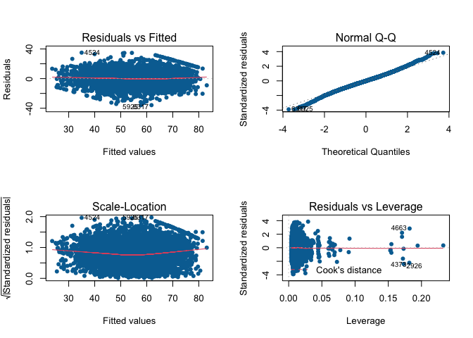

```r
par(mfrow=c(2,2))
plot(lm_fit$fit, pch = 16, col = '#006EA1')
```

```r
# Data frame of estimated coefficients
tidy(lm_fit)
```

```
## # A tibble: 50 × 5
##    term                               estimate std.error statistic  p.value
##    <chr>                                 <dbl>     <dbl>     <dbl>    <dbl>
##  1 (Intercept)                          52.4       3.84     13.7   8.94e-42
##  2 econ_hh_income$20,000 to $29,999     -0.103     0.620    -0.167 8.68e- 1
##  3 econ_hh_income$30,000 to $39,999      0.353     0.594     0.594 5.52e- 1
##  4 econ_hh_income$40,000 to $49,999      1.89      0.641     2.94  3.25e- 3
##  5 econ_hh_income$50,000 to $59,999      2.36      0.639     3.70  2.18e- 4
##  6 econ_hh_income$60,000 to $74,999      2.22      0.596     3.73  1.93e- 4
##  7 econ_hh_income$75,000 to $99,999      2.68      0.558     4.81  1.59e- 6
##  8 econ_hh_income$100,000 to $149,999    3.31      0.554     5.97  2.50e- 9
##  9 econ_hh_income$150,000 or more        4.77      0.595     8.02  1.33e-15
## 10 econ_savings0                        -3.45      1.92     -1.80  7.19e- 2
## # … with 40 more rows
```

```r
# Performance metrics on training data
glance(lm_fit)
```

```
## # A tibble: 1 × 12
##   r.squared adj.r.squared sigma statistic p.value    df  logLik    AIC    BIC
##       <dbl>         <dbl> <dbl>     <dbl>   <dbl> <dbl>   <dbl>  <dbl>  <dbl>
## 1     0.567         0.563  9.22      138.       0    48 -18579. 37259. 37585.
## # … with 3 more variables: deviance <dbl>, df.residual <int>, nobs <int>
```

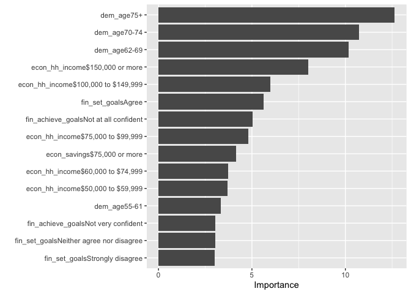

```r
# variable importance
vip(lm_fit, num_features=15)
```

**Testing Optimized Model**

```r
#predict(lm_fit, new_data = cfpb_test)

cfpb_results <- predict(lm_fit, new_data = cfpb_test) %>%
                            bind_cols(cfpb_test)
#cfpb_results

# RMSE on test set
rmse(cfpb_results, truth = cfpb_score, estimate = .pred)
```

```
## # A tibble: 1 × 3
##   .metric .estimator .estimate
##   <chr>   <chr>          <dbl>
## 1 rmse    standard        9.61
```

```r
rsq(cfpb_results, truth = cfpb_score, estimate = .pred)
```

```
## # A tibble: 1 × 3
##   .metric .estimator .estimate
##   <chr>   <chr>          <dbl>
## 1 rsq     standard       0.561
```

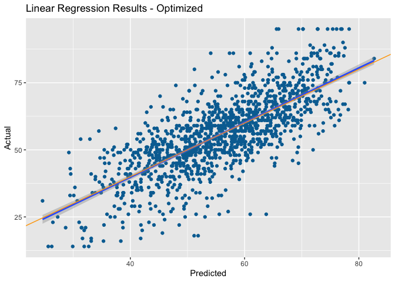

```r
ggplot(data = cfpb_results,
       mapping = aes(x = .pred, y = cfpb_score)) +
  geom_point(color = '#006EA1') +
  geom_smooth(method = lm) +
  geom_abline(intercept = 0, slope = 1, color = 'orange') +
  labs(title = 'Linear Regression Results - Optimized',
       x = 'Predicted',
       y = 'Actual')
```

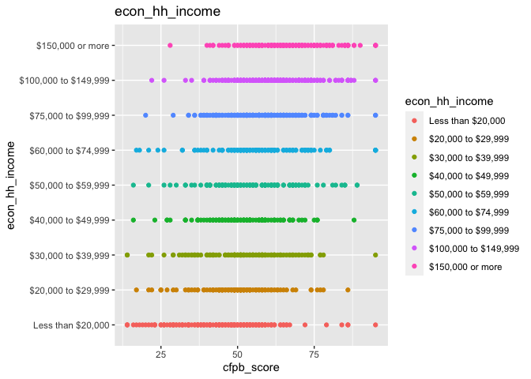

```r
# econ_hh_income
ggplot(data = cfpb_results) +
  geom_point(mapping = aes(x=cfpb_score, y=econ_hh_income, color=econ_hh_income)) +
  labs (title = "econ_hh_income")
```

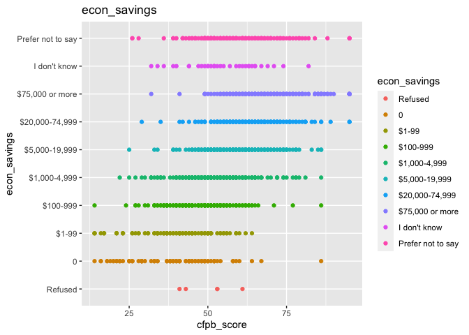

```r
# econ_savings
ggplot(data = cfpb_results) +
  geom_point(mapping = aes(x=cfpb_score, y=econ_savings, color=econ_savings)) +
  labs (title = "econ_savings")
```

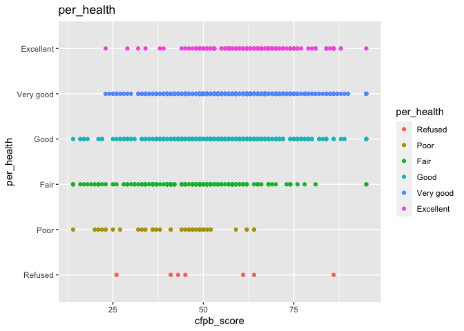

```r
# per_health
ggplot(data = cfpb_results) +
  geom_point(mapping = aes(x=cfpb_score, y=per_health, color=per_health)) +
  labs (title = "per_health")
```

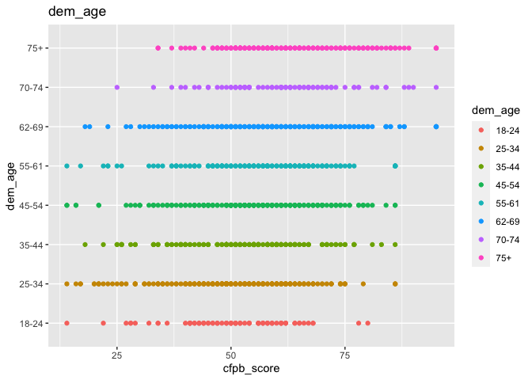

```r
# dem_age
ggplot(data = cfpb_results) +
  geom_point(mapping = aes(x=cfpb_score, y=dem_age, color=dem_age)) +
  labs (title = "dem_age")
```

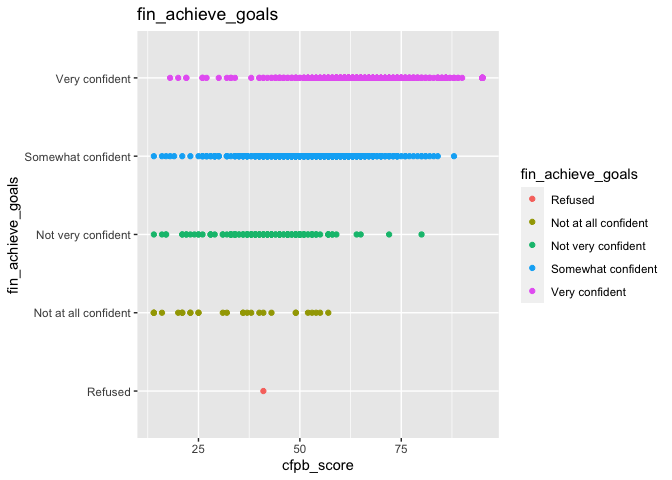

```r
# fin_achieve_goals
ggplot(data = cfpb_results) +
  geom_point(mapping = aes(x=cfpb_score, y=fin_achieve_goals, color=fin_achieve_goals)) +
  labs (title = "fin_achieve_goals")
```

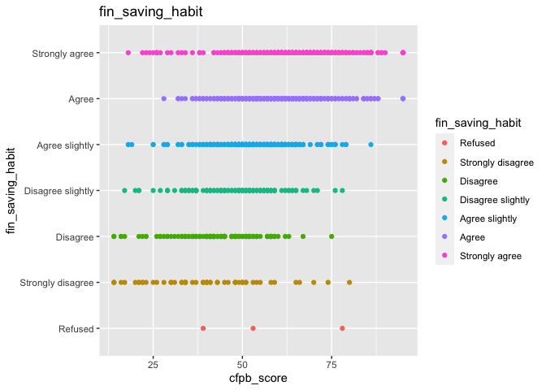

```r
# fin_saving_habit
ggplot(data = cfpb_results) +
  geom_point(mapping = aes(x=cfpb_score, y=fin_saving_habit, color=fin_saving_habit)) +
  labs (title = "fin_saving_habit")
```

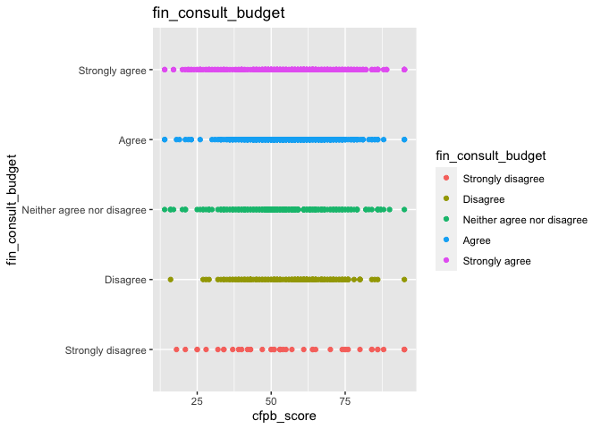

```r
# fin_consult_budget
ggplot(data = cfpb_results) +
  geom_point(mapping = aes(x=cfpb_score, y=fin_consult_budget, color=fin_consult_budget)) +
  labs (title = "fin_consult_budget")
```

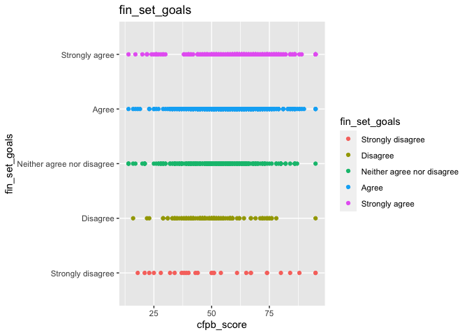

```r
# fin_set_goals
ggplot(data = cfpb_results) +
  geom_point(mapping = aes(x=cfpb_score, y=fin_set_goals, color=fin_set_goals)) +
  labs (title = "fin_set_goals")
```

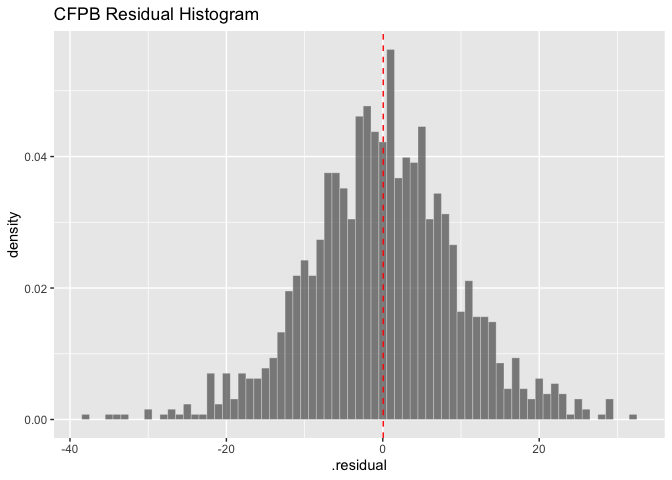

```r
# cfpb

cfpb_results$.residual <- cfpb_results$cfpb_score - cfpb_results$.pred


ggplot(cfpb_results,
    aes(.residual, y = stat(density))) +
    geom_histogram(binwidth = 1, alpha = 0.7, bins = 100, color="white",size = 0.1) +
    geom_vline(aes(xintercept = mean(.residual)), linetype = "dashed", color="red", size = 0.5) +
    scale_fill_brewer(palette="Spectral") +
    labs(title = "CFPB Residual Histogram")
```

```r
summary(cfpb_df$cfpb_score)
```

```
##    Min. 1st Qu.  Median    Mean 3rd Qu.    Max.
##   14.00   48.00   56.00   56.08   65.00   95.00
```

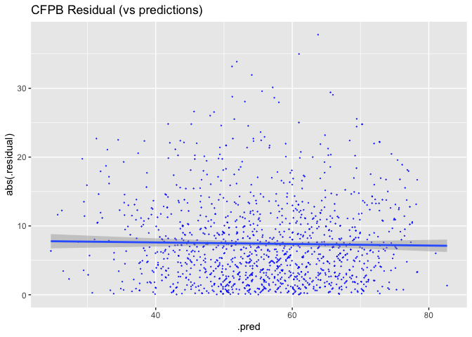

```r
cfpb_results %>%
#    filter(cfpb_score > 47 & cfpb_score < 66) %>%
    ggplot(
        aes(y = abs(.residual), x = .pred)) +
        geom_point(alpha = 0.7, color="blue",size = 0.1) +
        geom_smooth(method = lm) +
        #geom_vline(aes(xintercept = mean(.residual)), linetype = "dashed", color="red", size = 0.5) +
        scale_fill_brewer(palette="Spectral") +
        labs(title = "CFPB Residual (vs predictions)")
```

```r
summary(cfpb_df$cfpb_score)
```

```
##    Min. 1st Qu.  Median    Mean 3rd Qu.    Max.
##   14.00   48.00   56.00   56.08   65.00   95.00
```

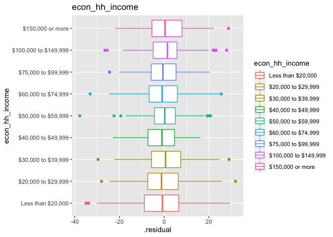

```r
# econ_hh_income
ggplot(data = cfpb_results) +
  geom_boxplot(mapping = aes(x=.residual, y=econ_hh_income, color=econ_hh_income)) +
  labs (title = "econ_hh_income")
```